[figure not shown]

[figure not shown]

# AI Tools for Evidence Aggregation and Literature Review

Day 3 · What to automate, what to check, and how sure you can be

Jonas Weinert

Impact Analytics

7 October 2026

## Why are you reading the literature?

1**Get an overview***What is the conversation on this topic?*

Good meansbalanced, the main camps and landmark papers

A miss costslittle: you will meet it later

Soany tool. Skim, move on

2**Check what's been done***What is closest to my question, and what is new in mine?*

Good meansthe nearest neighbours, read closely

A miss costsa referee finds the paper you missed

Sotwo tools, then read the nearest papers yourself

3**Systematic review / meta-analysis***What does all the evidence say?*

Good meansevery eligible study, reproducibly

A miss costsa biased answer that nobody can see

Soa tested workflow with a measured miss rate

The more a missed paper costs, the more care the process needs.

## Pulling data out of papers

For an overview or related work

A comparison table of the 10–20 closest papers: question, data, method, finding.

Purpose: spot the differentiator. Check the rows you will cite.

Systematic review / meta-analysis

A fixed coding form for every included study: effect sizes, samples, risk of bias.

Purpose: data for synthesis. Every value verified, ideally twice.

A rough table is fine for an overview. A systematic review / meta-analysis needs every value checked.

# Overviews and Related Work

## Which tool for what

| Job | Tools | Good at | Watch for |
| --- | --- | --- | --- |
| **Overview** | Deep research (ChatGPT, Gemini, Claude) | A cited overview in minutes | Web sources, misattributed claims |
| **Overview** | Gemini Notebook (NotebookLM) | Answers from your own sources | Only as good as what you upload |
| **Related work** | Elicit · Consensus · Undermind | Semantic search, comparison tables | Only what they index |
| **Related work** | Connected Papers · ResearchRabbit · Litmaps | Citation maps | Depends on your starting papers |
| **Systematic review / meta-analysis** | MetaScreener | Per-criterion screening, audit trail | You decide what humans check |

Not all of these are Bank-approved. Check the approved-tools list before using one for work, and the Day 1 classification rules before uploading anything non-public (drafts, search strategies, review corpora). ImpactAI (World Bank) was at the Day 1 Bazaar.

## General agent or a tool built for papers?

|  | General agent (ChatGPT, Gemini, Claude, Copilot) | Tool built for papers (Elicit, Consensus, MetaScreener) |
| --- | --- | --- |
| **The question** | One-off: “what are the main camps?” | The same search or screen, run on hundreds of papers |
| **What it searches** | The web | A paper index with abstracts and metadata |
| **What you do with the list** | Read it, then read the papers | Cite it, pool it, or report it as your method |
| **A missed paper** | Costs little | Costs a lot |
| **What is saved** | A chat transcript | Prompts, model and settings with every result |

Start with a general agent. Switch when you have to trust the list.

## How to ask, and how to check

Get an overview

Asking for the search terms and the gaps shows you where it looked.

Check what’s been done

Run the same question in a second tool. The demos show why.

**1**Ask for a DOI for every paper. Check each one before it goes in a draft

**2**Open the paper before you use a quote or a number from it

**3**Ask what it could not find. An empty answer there is a warning

**4**Save the export with tool, model and date

## Finding literature with your coding agent

Has anyone already done something like the SMARThealth Pregnancy trial?

literature-search skill · OpenAlex + Semantic ScholarClosest match: a 2026 **protocol** for the process evaluation of the SMARThealth Pregnancy hybrid cluster RCT (Votruba et al.), sharing 6 of its 54 references. Also close: a 2026 scoping review of digital health for hypertension in pregnancy in LMICs. doi.org/10.1177/17455057261425789

Is “Thompson & Raman (2023), Research Synthesis Methods” a real paper?

literature-search skill**Not found** in either database. Treat it as unverified and don’t cite it.

Find recent papers on …`lit.py search "…" --since 2022 --sort recent`

**agent**Turns the question into 3–6 key terms, e.g. `community health workers decision support`. A long sentence returns almost nothing: OpenAlex needs every word to match.

**API**OpenAlex `/works`, words matched in title and abstract · Semantic Scholar `/paper/search`, its own ranking. Two calls.

**script**Merges both lists, removes duplicates by DOI, marks where each paper was found (OA, S2, both), prints the hit counts.

**agent**Reads the abstracts before calling anything relevant. Reruns with synonyms (*lay health workers*, *mHealth*) and reports how the counts change.

← back to the example

Which papers does everyone cite?`lit.py core "…" --pool 200`

**agent**Same key terms as a search.

**API**OpenAlex: the 200 best-matching papers on the topic, with only their reference lists (`select=referenced_works`). Two calls of 100.

**script**Counts which works those 200 papers reference most, then fetches the top 15 by ID. One more call.

**agent**Reports each paper with "cited by N of the 200". Says that these are often older reviews and methods papers, so the newest study on the topic is unlikely to be here.

← back to the example

Has someone already done this?`lit.py similar DOI`, plus `search --sort recent` and `citing` on the same paper

**agent**Picks the closest paper it already knows and takes its DOI as the seed.

**API**OpenAlex: the seed's reference list → how often each reference is cited → papers that cite the seed's 40 least-cited references. Semantic Scholar: `/recommendations` for the seed, from text embeddings.

**script**Scores candidates by the references they share with the seed; sharing a niche trial counts far more than sharing a famous methods paper. Merges with the S2 list, which favours recent papers.

**agent**Reads the top matches and says how each differs: setting, population, method, outcome. Flags protocols and registrations: that is what a referee will point to.

← back to the example

Who has built on this paper?`lit.py citing DOI --sort recent`

**agent**Takes the DOI the user gives, or the one it found in an earlier step.

**API**OpenAlex: resolve the DOI to a work ID, then `/works?filter=cites:W…`, sorted by date or by citations. Two calls.

**script**Prints the table with the total number of citing papers.

**agent**Points out the newest follow-ups and any that look like replications or extensions of the user's own idea.

← back to the example

Is every reference in my draft real?`lit.py verify "full reference"`, once per reference

**agent**Runs the command on every reference in the draft, passing the full reference as written.

**API**With a DOI: OpenAlex `/works/doi:…`. Without: guesses the title from the text, then OpenAlex `title.search` and Semantic Scholar `/paper/search/match`.

**script**Compares titles: ≥ 0.9 FOUND, ≥ 0.7 UNCERTAIN, else NOT FOUND. For a found paper it also checks year, first author and volume/pages against the record (✓/✗).

**agent**Reports UNCERTAIN and NOT FOUND instead of fixing them silently. Tries the bare title or the DOI once more before calling a reference fabricated.

← back to the example

What you can ask your agent · click one to see what happens

“Find recent papers on …”

“Which papers does everyone in this field cite?”

“Has someone already done this?”

“Who has built on this paper?”

“Is every reference in my draft real?”

[Download the literature-search skill (ZIP)](https://github.com/dime-worldbank/ai-research-training/releases/download/literature-search-latest/literature-search.zip)

Unzip into `.agents/skills/` in your project. Works with Claude Code, Codex and other coding agents; uses the free OpenAlex and Semantic Scholar APIs, no account needed.

Same keyword engines underneath: read the abstracts, and verify every reference.

## Getting an overview with deep research

[figure not shown]

Gemini Deep Research: it proposes a plan you can edit, then searches and writes a cited report. ChatGPT and Claude work similarly.

Good for Main camps, key debates, search terms you had not thought of

Check Open every cited source. Is it a paper or a blog? Does it say what the report says?

## Search tools built for papers

[figure not shown]

**Elicit** · semantic search, then tables of extracted details

[figure not shown]

**Consensus** · asks the literature a question, summarises where papers agree

[figure not shown]

**Undermind** · an agent that follows citation trails over many rounds

Each searches a different index. Run the same question in two and compare.

## Demo · One question, two tools

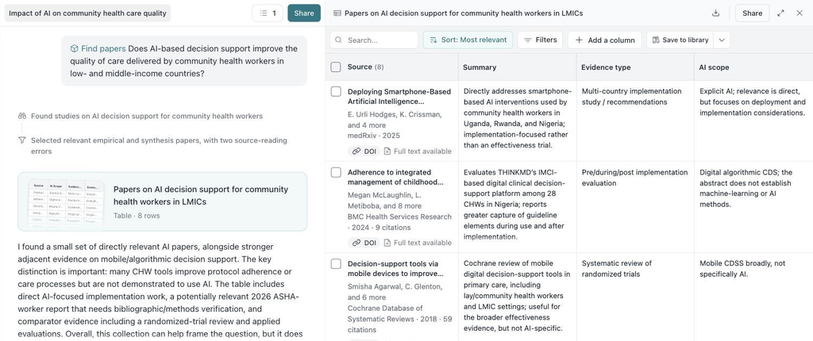

**Elicit** · *Does AI-based decision support improve the quality of care delivered by community health workers in low- and middle-income countries?*

8 papers. Its own **AI scope** column flags most of them as rule-based or general mHealth, not AIIts summary says so too: the set does not support treating digital decision-support effects as effects of AI[elicit.com/agent/add91450-6003-47d5-ba36-f30fd…](https://elicit.com/agent/add91450-6003-47d5-ba36-f30fd49308f9)

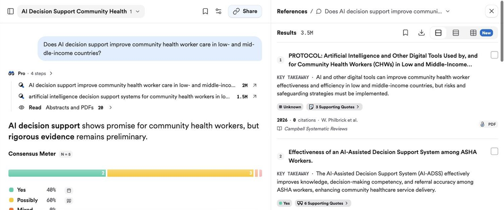

**Consensus** · *Does AI decision support improve community health worker care in low- and middle-income countries?*

“Shows promise … but rigorous evidence remains preliminary.” Meter: 2 Yes, 3 Possibly (N = 5)Top hit: a 2026 Campbell review **protocol** on AI tools used by CHWs in LMICs. Elicit did not return it[consensus.app/search/ai-decision-support-commu…](https://consensus.app/search/ai-decision-support-community-health/r2ApyCWtTvWFKv5N-fOfXQ/)

Same question, different papers. Look at what each answer rests on.

Real output, 6 Oct 2026. Click a screenshot to enlarge it.

## Demo · Has someone already done this?

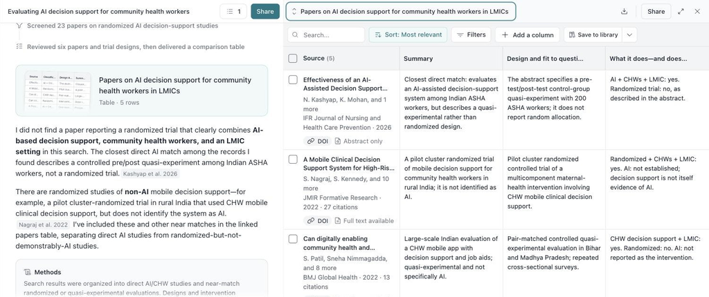

**Elicit** · *Has anyone run a randomized trial of AI decision support for community health workers in low- and middle-income countries?*

**No.** 23 papers screened, 5 near matches. None is a randomized trial of AI used by CHWsClosest: a quasi-experiment with 200 ASHA workers in India (Kashyap et al. 2026)[elicit.com/agent/a49002df-fdf7-4833-8b16-b7bd3…](https://elicit.com/agent/a49002df-fdf7-4833-8b16-b7bd3077322a)

[figure not shown]

**Consensus** · *the same question, word for word*

**Yes**, RCTs exist. Top hits: a CHW diabetes trial in Lesotho (2026) and a CHW pregnancy-screening pilot in India: both rule-based, not AIIts AI trials (e.g. an LLM trial in Kenya) involve clinical officers, not CHWs[consensus.app/search/ai-decision-support-commu…](https://consensus.app/search/ai-decision-support-community-health/4YqTUBl3TqGz1GdmAYH8vQ/)

Yes and no to the same question. Read the nearest papers yourself.

Real output, 6 Oct 2026. Click a screenshot to enlarge it.

## Comparing papers side by side

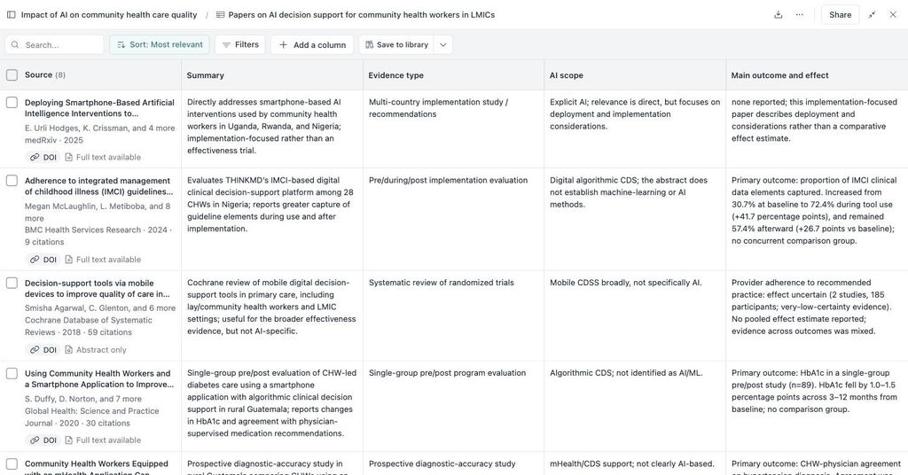

**Elicit** · *add a column: “Main outcome and effect”*

Filled for all 8 papers from the first search, e.g. IMCI guideline adherence 30.7% → 72.4%; HbA1c down 1.0–1.5 pointsAlso notes when there is **no comparison group**[elicit.com/agent/add91450-6003-47d5-ba36-f30fd…](https://elicit.com/agent/add91450-6003-47d5-ba36-f30fd49308f9)

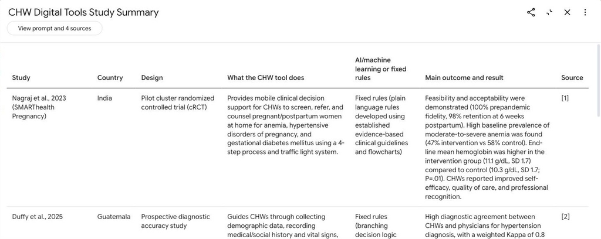

**Gemini Notebook** · *4 open-access papers from that table → Data table*

One row per study, each with a source number back to the paper3 of 4 tools are fixed rules. It reads one as “Bayesian logic” from the full text; Elicit’s abstract-based column said not AI[notebook.google.com/notebook/b7742dc0-c337-4f5…](https://notebook.google.com/notebook/b7742dc0-c337-4f5e-ab47-b4cb4dd5e5a6)

Check every row you cite against the paper.

Real output, 6 Oct 2026. Gemini Notebook was formerly NotebookLM.

## Where these tools go wrong

Invented sources

Citations that look real but do not exist, or do not say what is claimed

Ask for DOIs. Check each one

Coverage gaps

Paywalls, grey literature, non-English work, LMIC evidence

Run a second tool. Search Google Scholar and grey literature yourself

Moving models

Same prompt, new model version, different list

Record tool, model and date. Keep the export

Use the lists to find papers. Then read the papers.

# Systematic Review / Meta-Analysis

## What is at stake in screening

False exclusion

An eligible study is dropped and no human checks it.

**Lost for good, and invisible.** The pooled effect is biased and nobody can tell.

False inclusion

An ineligible study goes on to a human or to full text.

**Costs time, but recoverable.** Someone reads it and drops it.

And before screening starts

A study the search never finds is lost too. No screener can rescue it, so a systematic review / meta-analysis needs a broad search.

Screening rules exist to make false exclusions rare.

## One real review: 284,525 records, 17 studies

284,525 records found

68,049 titles and abstracts screened

2,163 about AI for frontline providers

229 empirically tested

57 in LMIC or low-resource settings

17 included

[figure not shown]

Sautmann & Weinert (2026), *Artificial Intelligence Interventions to Support Frontline Healthcare Workers in Low-Resource Settings: A Review*. By hand: 68,049 abstracts × 2 screeners × 2 min ≈ 4,500 hours. One LLM pass: about $11 per 1,000 papers.

Most of the work is saying No, tens of thousands of times.

## Too much to do by hand, and too risky

**≈4,500 h**to screen 68,049 abstracts twice by hand, at 2 minutes each

**13%**of eligible studies missed by a single human screener

**3%**still missed with two independent screeners

Too costly

Dual screening at this scale is months of skilled time, so teams narrow the search instead, and lose studies there.

Too risky

Humans miss too: **10.8%** of abstract decisions were wrong in experienced review teams. Abstract 40,000 looks like abstract 39,999.

The bar for a machine: miss no more than two human screeners, for far less work.

# How to Trust the Machine

## Trusting the machine, without vibe screening

Vibe screening

“Is this paper relevant to my review?” One prompt, one pass, accept the answer.

**You cannot say how many studies you lost, or which ones.**

A screening strategy

Each criterion answered separately, the same paper asked several times, a rule chosen from the measured error rates, then an audit.

**You can report recall, and defend it.**

Same rule as slide 2. For an overview, one prompt is fine. In a systematic review a missed paper costs a lot, so the workflow has to be tested before it runs.

Measure how the model fails before you let it exclude anything.

## A made-up review to work through

Cash transfers and school attendance

**1,000** papers to screen, **100** truly eligible

The LLM answers each criterion separately. A paper is excluded if **any** criterion says No

Invented numbers, chosen to make the logic easy to follow

**Population** children in LMICseasy

**Intervention** a cash transfereasy

**Design** a credible comparison grouptricky

**Outcome** attendance or enrolmenttricky

Would you let an LLM exclude papers on its own? At what error rate?

## Seven steps to a screening rule

1**Bootstrap**screen a sample many times

2**Read the inconsistency**which criteria flip?

3**Fix the criteria**rewrite, rerun

4**Reference answer**human labels or the modal answer

5**How Nos behave**wrong vs correct, on a rerun

6**Compare strategies**replay rules on the pilot

7**Choose, then check**explicit trade-off, fresh audits

human decisioncomputed from the pilot

A small pilot tells you how often the LLM is wrong, and on which criteria.

## Step 1 · Ask the same question many times

1 · Bootstrap2 · Inconsistency3 · Criteria4 · Reference5 · How Nos behave6 · Strategies7 · Choose

Paper A · clearly eligible

Paper B · eligible, confusing

Paper C · a genuine borderline

Paper D · clearly ineligible

NoYes 20 runs of the Design question

The pilot 100 papers × 20 runs each, about the cost of screening 2,000 papers once

What you get Same prompt, same abstract, different answers. So not one label per paper, but a **share of No answers**

## Step 2 · See which criteria flip

1 · Bootstrap2 · Inconsistency3 · Criteria4 · Reference5 · How Nos behave6 · Strategies7 · Choose

How often each criterion’s answer changes between runs of the same paper:

Population**1%**

Intervention**2%**

Design**18%**

Outcome**12%**

Most papers are stable 80 of 100 get the same decision in all 20 runs

Flips are on the borderline When the decision flips, 9 times in 10 only **one** criterion changed

Most flips come from two criteria and a few papers.

## Step 3 · Fix the criteria that flip

1 · Bootstrap2 · Inconsistency3 · Criteria4 · Reference5 · How Nos behave6 · Strategies7 · Choose

If the LLM can’t decide on a criterion, your co-screeners probably can’t either.

Rewrite, rerun the pilot, repeat until the flip rates are low. Human screening gets more consistent too.

## Step 4 · What counts as the right answer?

1 · Bootstrap2 · Inconsistency3 · Criteria4 · Reference5 · How Nos behave6 · Strategies7 · Choose

Human labels on the pilot Closest to the truth. Costs reviewer time, and humans err too: adjudicate disagreements.

The LLM’s majority answer Free once you have the runs. Gives a probability per paper, not just a label.

If the LLM is consistently wrong, so is the majority

If the LLM says No on an eligible paper in 15 of 20 runs, the majority says "ineligible" too. Only human labels catch those papers.

## Step 5 · Where do wrong Nos come from?

1 · Bootstrap2 · Inconsistency3 · Criteria4 · Reference5 · How Nos behave6 · Strategies7 · Choose

clearconfusingwrong No

The LLM wrongly says No 8% of the time on average. But not evenly. Of the **100 eligible** papers:

- **68** are clear: the LLM never says No
- **32** are confusing: it says No **1 time in 4**

One pass: 32 × ¼ = **8 wrong Nos**.

## Step 5 · Asking again catches most wrong Nos

1 · Bootstrap2 · Inconsistency3 · Criteria4 · Reference5 · How Nos behave6 · Strategies7 · Choose

**8**wrong Nos

ask  
again  
→

**2**still No  
8 × ¼

ask  
again  
→

**0.6**still No  
stickier: ~30%

ask  
again  
→

**0.2**still No

The naive calculation

"It is wrong 8% of the time, so a repeat is 8% × 8%." Predicts **0.6** left after one rerun.

What actually happens: 2 left

A paper that got a wrong No is probably a confusing one, so it repeats **1 time in 4**, not 8%.

Confusion also varies between papers: after two Nos in a row, the paper is likely one of the most confusing, so the repeat chance rises to ~30%. Each extra check helps, but less than you would expect.

## Step 5 · Correct Nos usually repeat

1 · Bootstrap2 · Inconsistency3 · Criteria4 · Reference5 · How Nos behave6 · Strategies7 · Choose

after 1 rerunafter 2after 3

Wrong No survives  
eligible paper, would be lost25%8%3%

Correct No survives  
ineligible paper, Design98%96%94%

Correct No survives  
ineligible paper, Outcome80%64%51%

Three checks catch 97% of wrong Nos and keep 94% of correct Design Nos. Outcome Nos wobble even when correct.

## Step 6 · Rules for what to do with a No

1 · Bootstrap2 · Inconsistency3 · Criteria4 · Reference5 · How Nos behave6 · Strategies7 · Choose

**Strategy 1** · trust one pass

[figure not shown]

**8 of 100 eligible lost** · 0 human reviews

**Strategy 6** · a human checks every single No

[figure not shown]

**0 lost** · 400 human reviews per 1,000 papers

full textexcludehuman reviewask the LLM againnumbers on branches: papers per 100 after the first pass

## Strategy 3 · Ask once more

1 · Bootstrap2 · Inconsistency3 · Criteria4 · Reference5 · How Nos behave6 · Strategies7 · Choose

[figure not shown]

2 of 100 lost

8 wrong Nos × ¼

28 reviews / 1,000

only papers that flip

Still loses 1 in 50

cheap, but not safe

## Strategy 4 · Confirm three times

1 · Bootstrap2 · Inconsistency3 · Criteria4 · Reference5 · How Nos behave6 · Strategies7 · Choose

[figure not shown]

Stops at the first Yes, so most papers need only 1–2 extra LLM calls.

0.2 of 100 lost

8 × 3% survive

66 reviews / 1,000

many are Outcome Nos that wobble

Why "every time"

A 2-of-3 vote would lose 1.6

## Why one rule does not fit every criterion

1 · Bootstrap2 · Inconsistency3 · Criteria4 · Reference5 · How Nos behave6 · Strategies7 · Choose

CriterionAnswer flips between runsA correct No is still No after 3 rechecksWhat a No tells youSo the rule is

**Population, Intervention**1–2%almost alwaysNearly always right. A rare slip shows up on one recheckRecheck once

**Design**18%94%Wrong Nos flip, correct Nos repeat: rechecks separate themConfirm 3×

**Outcome**12%51%Correct Nos flip too: rechecks cannot tell right from wrongSend to a human

Criteria stay inconsistent in different ways. Give each the rule its errors call for.

Flip rates from Step 2; survival of correct Nos from Step 5. Invented numbers for the made-up review.

## Strategy 5 · A different rule per criterion

1 · Bootstrap2 · Inconsistency3 · Criteria4 · Reference5 · How Nos behave6 · Strategies7 · Choose

[figure not shown]

Population, Intervention

one recheck: a No is nearly always right

Design

confirm 3×: correct Nos repeat, wrong ones flip

Outcome

to a human: correct Nos wobble anyway

Result

0.1 of 100 lost · 100 reviews / 1,000

## Papers lost vs. human reviews

1 · Bootstrap2 · Inconsistency3 · Criteria4 · Reference5 · How Nos behave6 · Strategies7 · Choose

1 · One pass8 lost0 reviews

2 · Vote 2 of 31.615

3 · Ask once more228

4 · Confirm 3×0.266

5 · By criterion0.1100

6 · Human every single No0400

eligible papers lost, of 100human reviews / 1,000 papers

Each extra review saves fewer papers than the last.

## Step 7 · Extra screens per paper saved

1 · Bootstrap2 · Inconsistency3 · Criteria4 · Reference5 · How Nos behave6 · Strategies7 · Choose

**1 → 2**One pass → Vote 2 of 3You screen **15** extra papersfor **6.4** averted misses**2**screens per averted miss

**2 → 4**Vote 2 of 3 → Confirm 3×You screen **51** extra papersfor **1.4** averted misses**36**screens per averted miss

**4 → 5**Confirm 3× → By criterionYou screen **34** extra papersfor **0.1** averted misses**340**screens per averted miss

**5 → 6**By criterion → Human every single NoYou screen **300** extra papersfor **0.1** averted misses**3,000**screens per averted miss

Decide before you look: how many extra screens is one averted miss worth to you?

Per 1,000 papers screened (100 eligible). A miss is an eligible paper excluded without a human seeing it. Strategy 3 is skipped: strategy 2 misses fewer papers for fewer screens. Or set a floor instead, e.g. “miss no more than dual human screening (3%)”.

## Step 7 · Finding no errors does not mean there are none

1 · Bootstrap2 · Inconsistency3 · Criteria4 · Reference5 · How Nos behave6 · Strategies7 · Choose

Pilot of 100 papers,  
**10** eligible, **0** lost**up to 30%**could still be lost

Enriched pilot,  
**50** eligible, **0** lost**up to 6%**could still be lost

Audit: **300** random  
exclusions, **0** eligible**up to 1%**of exclusions eligible

The rule of three Seeing **zero** problems in **n** checks means the true rate could still be about **3 / n** (95% upper bound).

So: enrich the pilot with likely includes, and audit the borderline (flips, split answers, tricky criteria) rather than random exclusions.

## Before you let an LLM screen

**1**Search broadly: screening cannot fix recall lost at the search

**2**Pilot with repeated runs, enriched for likely includes

**3**Rewrite the criteria that flip, then rerun

**4**Label part of the pilot by hand; do not trust the majority alone

**5**Fix your trade-off before comparing strategies

**6**Validate on fresh papers, audit the borderline, report recall honestly

# MetaScreener

## MetaScreener: reproducible bulk screening

**Upload**deduplicated CSV: title, abstract, DOI

→

**Criteria**you write yes/no/maybe per criterion

→

**LLM passes**1–3 full runs, or a bootstrap sample

→

**Moderate**you check boundary cases and disagreements

→

**Audit trail**labels, prompts, model, parameters

youtool

Per criterion A No names the criterion that failed

Repeated runs The strategy from the last section, built in

Reproducible Prompts, model and parameters saved with every label

Private Runs in the browser; bibliographies stay local

## Demo: MetaScreener

[figure not shown]

**MetaScreener** · upload your papers as a CSV, pick the fields to screen on, add your own criteria, start screening

[figure not shown]

Try it on your own review

Share your disagreements with us: we are validating across domains.

Method: Weinert et al. (forthcoming), *How much can we automate? Quantifying uncertainty to choose hybrid LLM–human screening strategies.*

## Next: decision models

An LLM

Writes its answer token by token, as text.

Its confidence is hidden or poorly calibrated, so to see uncertainty you **rerun it many times** (our Step 1).

A decision model

Returns a typed answer directly: yes/no, one option from a list, or a score.

Each answer comes with a **probability** in a single pass: act when confident, send to a human when not.

Example: Jev (TypeSafe AI, September 2026)

Trained for calibrated yes/no decisions. Vendor figures only so far, none on screening.

Screening is a set of yes/no questions. That is exactly what these models are built for.

## Thank you

This presentation was made using AI tools (Anthropic Claude Opus 5.5 & Fable 5.1) for design, layout, and content A/B testing.

# Appendix: Calculating screening uncertainty for SLRs & MAs

## A0 · Overview

1. **Decompose** eligibility into criteria; a paper is excluded if any criterion is No
2. **Pilot:** screen J papers R times each (e.g. 100 × 100)
3. **Reference answer** per paper and criterion: human labels, the majority vote, or a latent-class estimate
4. **Error structure:** wrong-No rates, whether wrong Nos repeat, how stable correct Nos are
5. **Candidate strategies:** for each first-pass pattern of Nos, exclude, review, or rerun k times
6. **Replay** every strategy exactly on the pilot runs, with confidence intervals from resampling papers
7. **Choose** on the frontier with an explicit exchange rate or recall floor
8. **Validate** out of sample, and audit in production

Full derivations, notation and scenarios: `presentation1/screening-uncertainty.qmd`.

## A1 · Notation

- **Papers and runs.** Papers $j = 1,\dots,J$ in the pilot, each screened $R$ times ($r = 1,\dots,R$). Criteria $c = 1,\dots,C$.
- **No-indicators.** $N_{jrc} = 1$ if run $r$ of paper $j$ answers No on criterion $c$. The **No-set** of a run is $S_{jr} = \{c : N_{jrc} = 1\}$, and $n_{jc} = \sum_r N_{jrc}$ counts a paper’s Nos on $c$.
- **Reference answer.** Paper $j$ is eligible ($j \in \mathcal E$) if no criterion’s reference answer is No: human labels where available, otherwise the modal answer across the $R$ runs.
- **Error rates.** For a paper that truly meets $c$, $\theta_{jc} = P(N_{jrc} = 1)$ is its **wrong-No rate**. For a paper that truly fails $c$, $\phi_{jc} = P(N_{jrc} = 1)$ is its **correct-No rate**.
- **Strategy.** A rule $a(S)$ that maps every first-pass No-set to an action: full text, exclude, human review, or $\text{rerun}(k)$. $\text{Rerun}(k)$: ask the flagged criteria again up to $k$ times; exclude only if every flagged criterion is No every time, otherwise send to a human.

In the fictional review: $J = 100$, $R = 20$, $C = 4$, and $|\mathcal E| = 10$ in a random pilot.

## A2 · What happens to one first run

Take paper $j$ with first run $r$ and No-set $S = S_{jr}$. Reruns are drawn from the paper’s other $R-1$ runs. Let $m_{jr}$ be how many of those still say No on every flagged criterion:

$$m_{jr} \;=\; \#\{\, r' \neq r \;:\; N_{jr'c} = 1 \ \text{for all } c \in S \,\}$$

For $\text{rerun}(k)$, all $k$ reruns must come from those $m_{jr}$ runs. That is a hypergeometric draw, so the exclusion and review probabilities are exact:

$$\pi_{jr} = \begin{cases} 1 & a(S) = \text{exclude} \\ \dfrac{\binom{m_{jr}}{k}}{\binom{R-1}{k}} & a(S) = \text{rerun}(k) \\ 0 & \text{otherwise} \end{cases}
\qquad
\rho_{jr} = \begin{cases} 1 & a(S) = \text{review} \\ 1 - \pi_{jr} & a(S) = \text{rerun}(k) \\ 0 & \text{otherwise} \end{cases}$$

With early stopping the loop ends at the first rerun that is not No, so the expected number of LLM calls is

$$\mathbb E[\text{calls}_{jr}] \;=\; \sum_{i=0}^{k-1} \binom{m_{jr}}{i} \Big/ \binom{R-1}{i}$$

## A3 · From runs to strategy figures

In production each paper is screened once, so each of its $R$ runs is an equally likely first pass. Average over them:

$$\bar\pi_j = \frac1R \sum_{r} \pi_{jr}, \qquad \bar\rho_j = \frac1R \sum_{r} \rho_{jr}$$

The figures on the main slides are then

$$\text{WrongExcl} = \frac{1}{|\mathcal E|} \sum_{j \in \mathcal E} \bar\pi_j,
\qquad
\text{Reviews per 1,000} = \frac{1000}{J} \sum_{j} \bar\rho_j,
\qquad
\text{Lost per 1,000} = \frac{1000}{J} \sum_{j \in \mathcal E} \bar\pi_j$$

- Everything is enumerated exactly: no simulation noise.
- **Uncertainty:** resample the $J$ papers with replacement (e.g. 3,000 times) and recompute. The paper, not the run, is the unit of uncertainty.
- **Enriched pilots:** weight each paper by the inverse of its sampling probability before averaging.

## A4 · Why a repeat is likelier than the average error

For an eligible paper with wrong-No rate $\theta$, two runs are independent **given** $\theta$. But $\theta$ differs across papers. Across papers with mean $\bar p = \mathbb E[\theta]$:

$$s_1 \;=\; P(\text{No on run 2} \mid \text{No on run 1}) \;=\; \frac{\mathbb E[\theta^2]}{\mathbb E[\theta]} \;=\; \bar p + \frac{\operatorname{Var}(\theta)}{\bar p}$$

The naive calculation uses $\bar p$. The extra term is large when errors concentrate in a few papers.

Fictional review 68% of eligible papers have $\theta = 0$, 32% have $\theta = 0.25$. Then $\bar p = 0.08$, $\operatorname{Var}(\theta) = 0.32 \cdot 0.25^2 - 0.08^2 = 0.0136$, and $s_1 = 0.08 + 0.0136/0.08 = 0.25$: **a wrong No repeats 1 time in 4, not 8%.**

## A5 · Why each extra check buys less

A wrong No survives $k$ confirmations with probability $\prod_{i=1}^{k} s_i$, where $s_i$ is the repeat chance after $i$ Nos in a row:

$$s_i \;=\; \frac{\mathbb E[\theta^{i+1}]}{\mathbb E[\theta^{i}]}
\qquad\text{estimated from the pilot as}\qquad
\hat s_i = \frac{\sum_{j} \binom{n_{jc}}{i+1} \big/ \binom{R}{i+1}}{\sum_{j} \binom{n_{jc}}{i} \big/ \binom{R}{i}}$$

- **Independence** assumes $s_i \equiv s_1$, so survival $= s_1^{\,k}$.
- **Two groups** (as in the fictional review): $s_i = 0.25$ for every $i$.
- **Confusion that varies**, e.g. $\theta \sim \text{Beta}(\alpha, \beta)$: $s_i = \dfrac{\alpha + i}{\alpha + \beta + i}$ **rises** with $i$. After a streak, the paper is probably one of the most confusing.
- **Correct Nos** use the same formula with $\phi$ in place of $\theta$ ($q_i$): criteria whose $q_i$ is well below 1 send many correctly excluded papers to humans when confirmed.

Latent-class models that assume conditional independence between runs run into the same problem.

## A6 · Choosing, and how sure you are

**Exchange rate.** With $\lambda$ = reviews you would spend to save one eligible paper:
$$\min_{a} \;\; \text{Reviews}(a) + \lambda \cdot \text{Lost}(a)$$

**Recall floor.** With $\varepsilon$ = the largest acceptable loss (e.g. dual human screening, 3%):
$$\min_{a} \;\; \text{Reviews}(a) \quad \text{s.t.} \quad \text{WrongExcl}^{\text{upper 95\%}}(a) \le \varepsilon$$

**Rule of three.** If $n$ independent checks find zero problems, the largest rate $p$ still consistent with that at 95% solves
$$(1 - p)^n = 0.05 \;\;\Rightarrow\;\; p = 1 - 0.05^{1/n} \;\approx\; \frac{\ln 20}{n} \;\approx\; \frac{3}{n}$$

## A7 · What the method cannot see

Consistent errors If the reference is the LLM’s own majority, papers it gets wrong on most runs look correctly excluded. Only human labels bound this.

Tuning on the pilot Choosing $k$ or criterion rules on the same pilot you evaluate on is optimistic. Validate on fresh papers.

Few eligible papers Wrong-exclusion rates rest on the eligible papers in the pilot: a handful can dominate. Enrich.

Pilot ≠ production Single-question reruns may behave differently from full-prompt runs, and the corpus may have a different share of eligible papers.

## A8 · Decision models and their older relatives

| Family | Example | Gives you | Watch for |
| --- | --- | --- | --- |
| **Decision model** | Jev (TypeSafe AI, 2026) | A probability per answer, in one fast, cheap call | Brand new, closed, vendor benchmarks only |
| **LLM token probabilities** | Compare P(“Yes”) with P(“No”), set a threshold for a target recall | Works with open models you already use | Raw probabilities are poorly calibrated: tune on seed papers |
| **Small zero-shot classifiers** | GLiClass, NLI models (~150M parameters) | Run on a laptop, one pass per paper | Weaker on nuanced criteria like study design |
| **Active learning** | ASReview | Learns from your labels, shows likely includes first | A human labels throughout, and needs a stopping rule |

Whatever the model, the strategy stays: check its probabilities on your pilot before you trust them.

Token probabilities: Wang et al. (2024), zero-shot generative LLMs for screening, ECIR. ASReview: van de Schoot et al. (2021), Nature Machine Intelligence. GLiClass: Knowledgator, Hugging Face.